# MATH 4773 Project 2

Robert Sandel

28 October, 2018

Abstract

Semiconductor fabrication processes are costly, complicated processes whose economic viability demands high yield from every location on each wafer. Deposition processes must provide uniformity, target achievement, and repeatability. The Oxide thickness ranges from 458 to 1498 angstroms and Deposition time ranges from 18 to 52 seconds. The resulting Polysilicon thickness was recorded using varying amounts of Oxide thickness and time. A first order interaction model was determined to be the best fit model with an Rsq value of 0.9553

# 1 Introduction

## 1.1 What are the variables?

| OXIDE | TIME | POLYSIL |
| --- | --- | --- |
| 1059 | 18 | 494 |
| 1049 | 35 | 853 |
| 1039 | 52 | 1090 |
| 1026 | 52 | 1058 |
| 1001 | 18 | 517 |
| 986 | 35 | 882 |

```
## [1] "OXIDE"   "TIME"    "POLYSIL"
```

### 1.1.1 Plot data

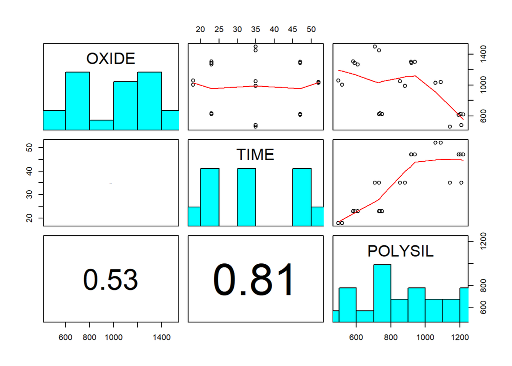

## 1.2 Data collection

A single silicon wafer is covered with oxide on both sides, placed in a quartz cham- ber, and heated to a temperature that depends on the processing time. Gaseous polysilicon, which is injected into the chamber, then bonds to the heated surface of the wafer. The wafer is heated by two banks of lamps, one bank of lamps above the wafer surface and the other below the surface. The temperature of the wafer is monitored by a single pyrometer that records the temperature at the wafer’s center. This temperature reading is used in a feedback loop that changes the power of the lamps to maintain a constant processing temperature. After the wafers are processed, polysilicon thickness is measured at 13 sites on each wafer. (HUGHES-OLIVER et al. 1998)

[figure not shown]

## 1.3 What is the story behind the data?

Material is deposited onto the wafer surface during several steps of wafer fabrication. This material must be deposited evenly across the entire wafer surface, close to the targeted thickness, and with little wafer-to-wafer variability. But unequal variances across the wafer and under different process conditions, as well as nonstationary correlation across a wafer, make these goals difficult to achieve, because traditional methods for optimizing deposition processes assume homogeneity and independence. (Mendenhall and Sincich 2016)

## 1.4 Why was it gathered?

The goal is to determine process settings that minimize wafer-to-wafer variability and deposit a uniform thickness of 1,000 angstroms of polysilicon across the upper surface of the wafer.

## 1.5 What is your interest in the data?

It is good data

## 1.6 What problem do you wish to solve?

Does oxide thickness and time affect the polysilicon thickness?

Does multicollinearity exist within this data set?

# 2 Theory needed to carry out MLR

## 2.1 Multicollinearity

Multicollinearity exists when two or more independent variables used in a regression model are correlated against each other so two or more of the independent variables used in the model for E(y) will contribute redundant information.

## 2.2 Correlation in detecting multicollinearity

One technique of determining collinearity is to calculate the coefficient of correlation r between each pair of independent variables in the model and test for evidence of positive or negative correlation. If one or more of the r values is statistically different from 0, the variables in question are correlated and a severe multicollinearity problem may exist

## 2.3 T-test and F-test for detecting multicollinearity

Using the T-test for individual beta estimates with the F-test for overall model adequacy can also help determine if multicollinearity exists. When this happens the parameters will have an opposite sign from what is expected.

$$E(y)=\beta_0+\beta_1x_1+\beta_2x_2$$

In the model above, we are determing whether the $\beta_1$ and $\beta_2$ values are non-significant using the F-statistic. With this method the null being tested is whether $H_0:\beta_1=\beta_2=0$ with the alternative being that one or more of the betas are non zero. But from the F statistic we determing that the model is highly significant. This is a contradiction that indicates a possibility of multicollinearity

## 2.4 Summary of detecting multicollinearity

$$E(y) = \beta_0 + \beta_1 x_1 + \beta_2 x_2 + \ldots + \beta_k x_k$$

From the model shown above, the following are indicators of multicolinearity:

1. Significant correlations between pairs of independent variables in the model
2. Non-significant T-tests for the individual parameters when the F-test for overall model adequacy $H_0: \beta_1=\beta_2=\ldots=\beta_k=0$ is significant
3. Opposite signs (from what is expected) in the estimated parameters

## 2.5 Result

In order to determine if the data has multicolinearity, the correlation coefficients are calculated below:

|  | OXIDE | TIME | POLYSIL |
| --- | --- | --- | --- |
| OXIDE | 1.0000 | 0.0020 | -0.5334 |
| TIME | 0.0020 | 1.0000 | 0.8123 |
| POLYSIL | -0.5334 | 0.8123 | 1.0000 |

## 2.6 Determining Model Selection

During analysis of a dataset, multiple models have been created and tested. In order to determine the best model, we will be looking into the Akaike Information Criterion and adjusted $R^2$.

## 2.7 Akaike Information Criterion (AIC)

The Akaike Information Criterion (AIC) is an estiator of the relative quality of statistical models for a give set of data. AIC estimates the quality of the model relative to other models and is a means of model selection. The AIC is defined below:

$$AIC = 2k - 2 \ln{\hat{L}}$$
where $k$ is the number of parameters and $\hat{L}$ is the maximum likelihood. (Konishi and Kitagawa 2008)

# 3 Model selection

1. First order model
   $$E(y)=\beta_0+\beta_1x_1+\beta_2x_2$$
2. Second order model
   $$E(y)=\beta_0+\beta_1x_1+\beta_2x_2+\beta_3x_1^2+\beta_4x_2^2$$
3. First order interaction model
   $$E(y)=\beta_0+\beta_1x_1+\beta_2x_2+\beta_3x_1x_2$$
4. Second order interaction model
   $$E(y)=\beta_0+\beta_1x_1+\beta_2x_2+\beta_3x_1^2+\beta_4x_2^2+\beta_5x_1x_2$$
5. AIC selected model
   $$E(y)=\beta_0+\beta_1x_1+\beta_2x_2+\beta_3x_1x_2$$
   The AIC selected model is equivalent to hte first order interaction model, so we are interester in the first two models

```r
y.lm1=lm(data=WAFER2,POLYSIL~OXIDE+TIME)
y.lm2=lm(data=WAFER2,POLYSIL~OXIDE+TIME+OXIDE*TIME)
y.lm3=lm(data=WAFER2,POLYSIL~OXIDE+TIME+I(OXIDE)^2+I(TIME)^2)
y.lm4=lm(data=WAFER2,POLYSIL~OXIDE+TIME+I(OXIDE)^2+I(TIME)^2+OXIDE*TIME)

AIC.selected <- step(y.lm4,direction="both",trace=FALSE)
summary(AIC.selected)
```

```
##
## Call:
## lm(formula = POLYSIL ~ OXIDE + TIME + OXIDE:TIME, data = WAFER2)
##
## Residuals:
##     Min      1Q  Median      3Q     Max
## -69.753 -31.882  -1.168  22.350 151.316
##
## Coefficients:
##               Estimate Std. Error t value Pr(>|t|)
## (Intercept) 394.971152 144.779816   2.728   0.0138 *
## OXIDE        -0.116937   0.141931  -0.824   0.4208
## TIME         24.136281   3.981648   6.062 9.93e-06 ***
## OXIDE:TIME   -0.007541   0.003903  -1.932   0.0693 .
## ---
## Signif. codes:  0 '***' 0.001 '**' 0.01 '*' 0.05 '.' 0.1 ' ' 1
##
## Residual standard error: 54.96 on 18 degrees of freedom
## Multiple R-squared:  0.9553, Adjusted R-squared:  0.9478
## F-statistic: 128.2 on 3 and 18 DF,  p-value: 2.462e-12
```

## 3.1 AIC

|  | AIC |
| --- | --- |
| Model 1 | 246.4545 |
| Model 2 | 244.3089 |
| Model 3 | 246.4545 |
| Model 4 | 244.3089 |

from this we observe that model 2 and model 4 have the lowest AIC, but because we want the simplest model that explains the data, we choose model 2

## 3.2 Multiple $R^2$

The multiple $R^2$ coefficient represents the fraction of the sample varation of the $y$ value that attrubutes to the regression model. This value is defined below:

$$R^2 = 1- \dfrac{\sum (y_i -\hat{y_i})^2}{\sum (y_i - \bar{y_i})} = 1-\dfrac{SSE}{SS_{yy}}$$

## 3.3 Adjusted $R^2$

The adjusted $R^2$ value compares the explanatory power of the regression model that contains multiple predictors. The adjusted $R^2$ is used to replace the $R^2$ in regression as this value can have problems in the model selection.

Each time a new variable is added to the model, the $R^2$ value increases. This can become problematic as there may cause overfitting to the dataset. This problem also occurs in higher order polynomials as noise is added to the dataset.

The adjusted $R^2$ is a modified version of the $R^2$ that penelizes the model for having too many variables. The adjusted $R^2$ equation is shown below:

$$R_{adj}^2 = 1 - \dfrac{n-1}{n-(k+1)}(1-R^2)$$

In model selection, with many of the models having high $R^2$ values, the next option is to choose the model based on its adjusted $R^2$.

|  | Ra2 |
| --- | --- |
| Model 1 | 0.9403 |
| Model 2 | 0.9478 |
| Model 3 | 0.9403 |
| Model 4 | 0.9478 |

Since we want to choose the simplest model that explains the most data, we choose model 2

# 4 Validity with mathematical expressions

## 4.1 Checks on validity

In order to apply a regression analysis to determine the results of the data, we must provide some answers on errors of the data. This is done by proving the following: 1. $E(\epsilon)=0$ 2. $V(\epsilon)=\sigma^2$ 3. $\epsilon$ is normally distributed 4. $\epsilon$ values are independent

### 4.1.1 Errors distributed Normally

$$\epsilon_i \sim N(0,\sigma^2)$$

#### 4.1.1.1 Shapiro-wilk

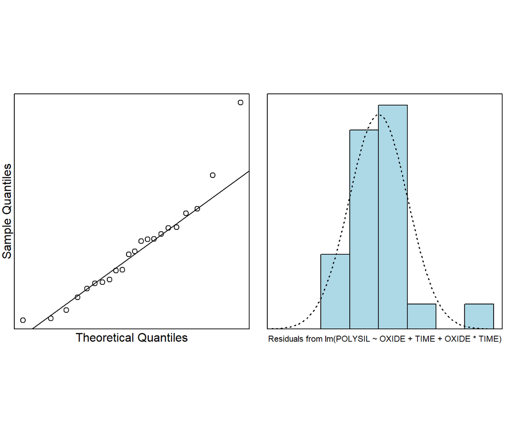

```r
normcheck(y.lm)
```

### 4.1.2 Constant variance

```r
anova(y.lm)
```

|  | Df | Sum Sq | Mean Sq | F value | Pr(>F) |
| --- | --- | --- | --- | --- | --- |
| OXIDE | 1 | 346003.64 | 346003.638 | 114.549336 | 3.109337e-09 |
| TIME | 1 | 804543.22 | 804543.221 | 266.355267 | 3.116876e-12 |
| OXIDE:TIME | 1 | 11274.07 | 11274.073 | 3.732439 | 6.926219e-02 |
| Residuals | 18 | 54370.16 | 3020.564 | NA | NA |

#### 4.1.2.1 Residual vs fitted values

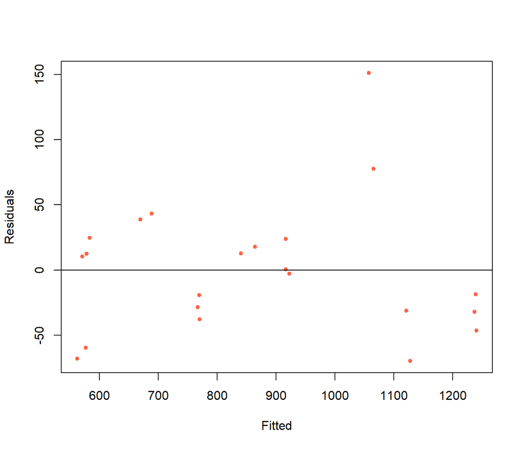

```r
plot(residuals(y.lm)~fitted(y.lm),xlab="Fitted",ylab="Residuals",pch=20, col="tomato")
abline(h=c(-3*54.96,0,3*54.96))
```

### 4.1.3 Zero mean value of $\epsilon$

So far we have determined that the true relationsip of the data is linear. Therefore we hypothesise the relationship as:

$$y = \beta_0 + \beta_1 x_1 + \beta_2 x_2 + \beta_3 x_1 x_2+ \epsilon$$

We rearrange the equation as follows:

$$\epsilon = y - \beta_0 - \beta_1 x_1 - \beta_2 x_2 -\beta_3 x_1 x_2$$

It can then be shown that,

$$E(\epsilon) = E(y) - \beta_0 - \beta_1 x_1 - \beta_2 x_2 -\beta_3 x_1 x_2$$

Substituting the expression for the true $E(y)$ we have,

$$E(\epsilon) = \beta_0 + \beta_1 x_1 + \beta_2 x_2 + \beta_3 x_1 x_2 - ( \beta_0 + \beta_1 x_1 + \beta_2 x_2 + \beta_3 x_1 x_2 )$$

This is simplified down to

$$E(\epsilon) = 0$$

### 4.1.4 Independence of data

```r
cor(WAFER2)
```

```
##              OXIDE      TIME    POLYSIL
## OXIDE    1.0000000 0.0020393 -0.5333833
## TIME     0.0020393 1.0000000  0.8122537
## POLYSIL -0.5333833 0.8122537  1.0000000
```

## 4.2 Summary lm object

```r
summary(y.lm)
```

```
##
## Call:
## lm(formula = POLYSIL ~ OXIDE + TIME + OXIDE * TIME, data = WAFER2)
##
## Residuals:
##     Min      1Q  Median      3Q     Max
## -69.753 -31.882  -1.168  22.350 151.316
##
## Coefficients:
##               Estimate Std. Error t value Pr(>|t|)
## (Intercept) 394.971152 144.779816   2.728   0.0138 *
## OXIDE        -0.116937   0.141931  -0.824   0.4208
## TIME         24.136281   3.981648   6.062 9.93e-06 ***
## OXIDE:TIME   -0.007541   0.003903  -1.932   0.0693 .
## ---
## Signif. codes:  0 '***' 0.001 '**' 0.01 '*' 0.05 '.' 0.1 ' ' 1
##
## Residual standard error: 54.96 on 18 degrees of freedom
## Multiple R-squared:  0.9553, Adjusted R-squared:  0.9478
## F-statistic: 128.2 on 3 and 18 DF,  p-value: 2.462e-12
```

### 4.2.1 3D model

```r
scatter3d(POLYSIL~OXIDE+TIME+OXIDE*TIME,WAFER2, fit=c("linear","quadratic"))
rgl::rglwidget()
```

[interactive chart not shown]

There appears to be a linear relationship between oxide and time to polysil

### 4.2.2 Interpretation of multiple R squared

95.53% of the variability in the data is explained by this model. We can conclude that this model fits well with the data.

### 4.2.3 Interpretation of F statistic

With an F-statistic of 128.2 on 3 and 18 degrees of freedom and a p-value of 2.462e-12, we deduce the rejection region to be greater than 3.1599076 at $\alpha=0.05$. We reject the null that $H_0:\beta_1=\beta_2=\beta_3=0$ and accept the alternative that at least one beta estimate is non-zero. We conclude that the f test indicates that the multiple regression model is statistically useful for predicting y

### 4.2.4 Interpretation of all point estimates

```r
cf=coef(y.lm)
cf
```

```
##   (Intercept)         OXIDE          TIME    OXIDE:TIME
## 394.971151518  -0.116937177  24.136280761  -0.007540987
```

$\beta_0$ is the y-intercept at 394.9712 when both oxide ($x_1$) and time ($x_2$) are zero.

$\beta_1$ is -0.1169 causes a shift along the $x_1$ axis.

$\beta_2$ is 24.1363 causes a shift along the $x_2$ axis.

$\beta_3$ is -0.0075 and controls the rotation of the surface

### 4.2.5 Confidence intervals

```r
ciReg(y.lm,conf.level = 0.95)
```

```
##             95 % C.I.lower    95 % C.I.upper
## (Intercept)       90.80005         699.14226
## OXIDE             -0.41512           0.18125
## TIME              15.77115          32.50141
## OXIDE:TIME        -0.01574           0.00066
```

### 4.2.6 Check on outliers using cooks plots

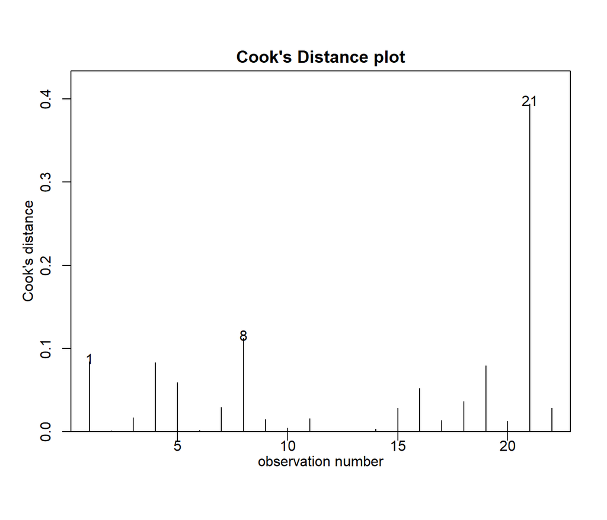

```r
cooks20x(y.lm)
```

### 4.2.7 Prediction intervals

```r
x1.n = mean(WAFER2$OXIDE)
x2.n = mean(WAFER2$TIME)
newdata = data.frame(OXIDE=x1.n,TIME=x2.n)
predict(y.lm,newdata,interval="prediction",level=0.95)
```

```
##        fit      lwr      upr
## 1 867.4216 749.3605 985.4826
```

# 5 Conclusion

## 5.1 Sugges Tions

In order to improve the model, a larger data set would be beneficial to building the model.

# References

HUGHES-OLIVER, Jacqueline M., Jye-Chi Lu, Joseph C. Davis, and d Ronald S. GYURCSIK. 1998. “Correction: Achieving Uniformity in a Semiconductor Fabrication Process Using Spatial Modeling.” *Journal of the American Statistical Association* 93 (443): 36–41. doi:10.2307/2669908.

Konishi, Sadanori, and G. Kitagawa. 2008. *Information Criteria and Statistical Modeling*. Springer.

Mendenhall, William, and Terry Sincich. 2016. *Statistics for Engineering and the Sciences*. CRC Press, Taylor & Francis Group.